# 36-315 Lab 09: Processing Text, Word Clouds, and Sentiment Analysis

SOLUTIONS

Due Saturday, November 20, 2021 (12pm via Gradescope)

# Problem 1: Processing Text and Making Word Clouds (35 points)

In Lab3 (a long time ago) we worked with a dataset containing tweets (from Twitter) about airlines, but we never looked at the text data! Now, in our last lab, we’re going to revisit that dataset and look at the text. Here’s the dataset:

```r
library(tidyverse)
airline_tweets <- read_csv("https://raw.githubusercontent.com/zjbranson/315Fall2021/main/TweetsSimplified.csv")
```

Since you probably don’t remember this dataset from Lab3 (I think it would be bizarre if you did): This dataset contains information about Tweets made about airlines. Most of these Tweets are made while someone is waiting to board a flight. Here are the variables in this dataset:

- `text`: The text of each tweet. This is the main variable we will focus on.
- `airline`: The airline that the Tweet was about.
- `airline_sentiment`: The estimated sentiment of each tweet, labeled as “positive”, “negative”, or “neutral.” For the sake of this lab, we will take these sentiment labels at face value; we will explore sentiment further in the homework.
1. (5pts) First, let’s do some preprocessing of the raw text, contained in the `text` column. This code is taken directly from the `R` Demo. (You’ll have to do similar preprocessing in Homework11.)

```r
library(tm)
#first, let's work with the titles
#redefine as Corpus
tweets = Corpus(VectorSource(airline_tweets$text))
#change to lowercase
tweets <- tm_map(tweets, content_transformer(tolower))
# Remove punctuations
tweets <- tm_map(tweets, removePunctuation)
# Eliminate extra white spaces
tweets <- tm_map(tweets, stripWhitespace)
```

Then, the following code creates a Document-Term Matrix:

```r
DocumentTermMatrix(tweets, control = list(stopwords = FALSE, stemming = FALSE))
```

```
## <<DocumentTermMatrix (documents: 14640, terms: 16716)>>
## Non-/sparse entries: 192541/244529699
## Sparsity           : 100%
## Maximal term length: 46
## Weighting          : term frequency (tf)
```

Note that we *did not* remove stop words or perform stemming when creating this Document-Term matrix. Write a new line of code that creates a Document-Term matrix where you *do* remove stop words and perform stemming. Define that Document-Term matrix as `dtm.tweets`. After you’ve written that line of code: How many columns (or terms) are in the resulting Document-Term matrix?

```r
dtm.tweets = DocumentTermMatrix(tweets, control = list(stopwords = TRUE, stemming = TRUE))
dtm.tweets
```

```
## <<DocumentTermMatrix (documents: 14640, terms: 13743)>>
## Non-/sparse entries: 143255/201054265
## Sparsity           : 100%
## Maximal term length: 46
## Weighting          : term frequency (tf)
```

*From the above output, we see that there are 13743 columns/terms in the Document-Term matrix.*

2. (15pts) Now we are going to make a word cloud using the `wordcloud()` function. There are two important arguments within the `wordcloud()` function:
- `words`: A vector of unique words in your set of documents.
- `freq`: A vector of word frequencies across documents (i.e., the frequency of each word in `words`).

First, define `tweets.words` as the vector of unique words in your set of documents. Note that the columns of `dtm.tweets` correspond to the unique words in the tweets; thus, you can use `colnames()` to define `tweets.words`.

```r
tweets.words = colnames(dtm.tweets)
```

Now use your Document-Term matrix to compute the total word frequencies across all tweets. To do this, it’ll be helpful to first convert `dtm.tweets` to a matrix class (code is already provided below to do this). So, think about how you can use this matrix to compute the vector of total word frequencies across all tweets. Call this vector `tweets.freqs`. If you’re unsure how to do this, ask for help.

```r
#convert the document-term matrix to a matrix
#(this will only work if you defined dtm.tweets in Part A)
dtm.tweets.mat = as.matrix(dtm.tweets)
tweets.freqs = colSums(dtm.tweets.mat)
```

After you’ve successfully defined `tweets.words` and `tweets.freqs`: Which words were used more than 1000 times? All you have to do is write a line of code that prints out words used more than 1000 times in this dataset.

```r
tweets.words[which(tweets.freqs > 1000)]
```

```
##  [1] "americanair"  "can"          "cancel"       "flight"       "get"
##  [6] "help"         "hour"         "jetblu"       "now"          "southwestair"
## [11] "thank"        "unit"         "usairway"
```

3. (15pts) Once you’ve successfully defined `tweets.words` and `tweets.freqs` (in Part B), use the `wordcloud()` function to make a word cloud of the tweets (be sure that you’ve installed the `wordcloud` `R` package). When implementing the `wordcloud()` function, specify the arguments `words`, `freq`, `random.order`, `max.words`, and `colors` to make a word cloud that looks appealing to you. (See the `R` demo or the help documentation for `wordcloud()` for details about these arguments, or ask for help.)

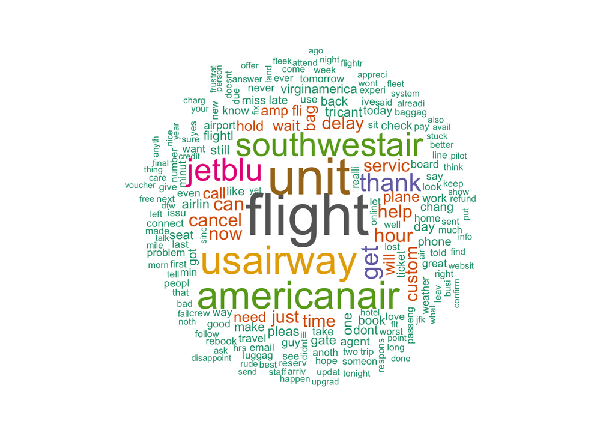

```r
library(wordcloud)
wordcloud(words = tweets.words, freq = tweets.freqs, max.words = 200, random.order = FALSE, colors=brewer.pal(8, "Dark2"))
```

After you’ve made your word cloud, summarize your main takeaways from the word cloud in 1-2 sentences.

# Problem 2: Comparing Word Clouds, Comparison Word Clouds (40 points)

1. (20pts) Now create a separate word cloud for Southwest, American, and jetblue (this is contained in the `airline` column of the dataset). To do this, follow these steps:
- Make American, Southwest, and JetBlue datasets by subsetting the `airline_tweets` dataset. Call these `american`, `southwest`, and `jetblue`.

```r
#subsets for different airlines
american <- filter(airline_tweets, airline == "American")
southwest <- filter(airline_tweets, airline == "Southwest")
jetblue <- filter(airline_tweets, airline == "JetBlue")
```

- Similar to Problem 1A, we will preprocess the `text` from each of these three subsets. To save you time, here’s a function you can use to do some of the preprocessing in Problem 1A:

```r
preprocessText = function(text){
    text = Corpus(VectorSource(text))
    #change to lowercase
    text <- tm_map(text, content_transformer(tolower))
    # Remove punctuations
    text <- tm_map(text, removePunctuation)
    # Eliminate extra white spaces
    text <- tm_map(text, stripWhitespace)
    return(text)
}
```

Then, using this function, write code that defines preprocessed text for the three airlines; call these `american.text`, `southwest.text`, and `jetblue.text`.

```r
american.text = preprocessText(american$text)
southwest.text = preprocessText(southwest$text)
jetblue.text = preprocessText(jetblue$text)
```

- For each of the three subsets, repeat the other parts of Problem 1 (create a Document-Term matrix where you remove stop words and perform stemming, and compute the `words` and `freq` for each matrix). Then, create a word cloud for each subset, and arrange the results into a 1x3 grid using `par(mfrow=c(1,3))`. Please also set each word cloud to a different color, such that it is easier to differentiate each word cloud. So that your word clouds fully display, please use the following code block when displaying your word clouds:

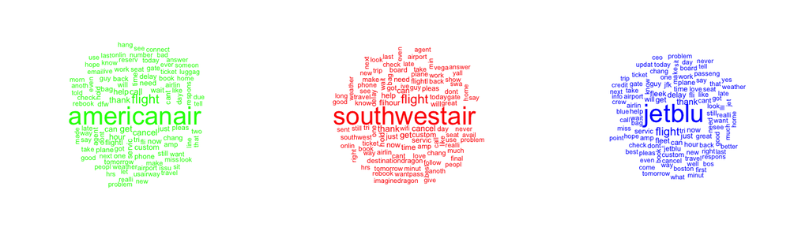

```r
#change the margins for better display
par(mar = c(1, 2, 1, 2))

#creating the document-term matrices
dtm.tweets.american = DocumentTermMatrix(american.text, control = list(stopwords = TRUE, stemming = TRUE))
dtm.tweets.southwest = DocumentTermMatrix(southwest.text, control = list(stopwords = TRUE, stemming = TRUE))
dtm.tweets.jetblue = DocumentTermMatrix(jetblue.text, control = list(stopwords = TRUE, stemming = TRUE))

#getting the words and their frequencies
tweets.american.words = colnames(dtm.tweets.american)
tweets.american.freqs = colSums(as.matrix(dtm.tweets.american))

tweets.southwest.words = colnames(dtm.tweets.southwest)
tweets.southwest.freqs = colSums(as.matrix(dtm.tweets.southwest))

tweets.jetblue.words = colnames(dtm.tweets.jetblue)
tweets.jetblue.freqs = colSums(as.matrix(dtm.tweets.jetblue))

#arrange the word clouds in a grid
par(mfrow=c(1,3))
wordcloud(words = tweets.american.words, freq = tweets.american.freqs, max.words = 100,
    random.order = FALSE, colors = "green", scale=c(2,.5))
wordcloud(words = tweets.southwest.words, freq = tweets.southwest.freqs, max.words = 100,
    random.order = FALSE, colors = "red", scale=c(2,.5))
wordcloud(words = tweets.jetblue.words, freq = tweets.jetblue.freqs, max.words = 100,
    random.order = FALSE, colors = "blue", scale=c(2,.5))
```

- Then, compare and contrast the word clouds in 1-2 sentences.

*We see that words like flight and thank are very common in all three word clouds. Meanwhile, we see that the different airlines are the most common word in each of their respective word clouds. Otherwise, most of the words are fairly similar, although I was entertained to see that the word “fleek” was distinctly in the JetBlue word cloud. (Note: If you didn’t use the `scale` argument - which you were not expected to - the word “southwestair” actually wouldn’t have shown up in the Southwest word cloud, because it was too large for the display. The default scale range is `scale = c(4, .5)`, and in the above I made the range smaller so that the word “southwestair” would display on the word cloud.)*

2. (20pts) Now make a comparison word cloud for American and JetBlue. To get you started, here’s code you can use to preprocess the American and JetBlue text to get it in the format necessary to make a word cloud:

```r
tweetsAmericanJetBlue = tm:::c.VCorpus(american.text, jetblue.text)
tweetsAmericanJetBlue = tm_map(tweetsAmericanJetBlue, PlainTextDocument)
tweetsAmericanJetBlue = tm_map(tweetsAmericanJetBlue, removeWords, stopwords("english"))
tweetsAmericanJetBlue = tm_map(tweetsAmericanJetBlue, stemDocument)
```

The above code requires you to have defined `american.text` and `jetblue.text`, which you should have defined in Part A. Then, the following code creates a Term-Document matrix using the function `TermDocumentMatrix()`, with TF-IDF weights:

```r
tdm_both <- TermDocumentMatrix(tweetsAmericanJetBlue, control = list(weighting = weightTfIdf))
#convert to a matrix class
tdm_both = as.matrix(tdm_both)
```

Note that this is a **Term-Document** matrix; thus, terms are in the rows and documents (tweets) are in the columns!

Then, using the resulting `tdm_both`, do the following:

- For each word, compute the total TF-IDF weighting for American. **Hint**: Use `rowSums()` on the Term-Document Matrix, but only for the columns corresponding to American (thus, you’ll need to figure out how many documents are in `American`). Do the same thing for JetBlue (thus, you’ll need to figure out how many documents are in `jetblue`).

*Just by looking at `american.text` and `jetblue.text`, we can find out how many documents there are:*

```r
american.text
```

```
## <<SimpleCorpus>>
## Metadata:  corpus specific: 1, document level (indexed): 0
## Content:  documents: 2759
```

```r
jetblue.text
```

```
## <<SimpleCorpus>>
## Metadata:  corpus specific: 1, document level (indexed): 0
## Content:  documents: 2222
```

*Thus, the total word counts across each airline is:*

```r
#sum across the united and southwest columns
tdm_american_sum = rowSums(tdm_both[,1:2759])
tdm_jetblue_sum = rowSums(tdm_both[,2760:(2759 + 2222)])
```

- Using `cbind()`, combine the two aforementioned row-sums into a two-column matrix; put the row-sums for American in the first column and the row-sums for JetBlue in the second column. Call this matrix `tdm_both_sum`.

```r
#combine these two aggregations
tdm_both_sum = cbind(tdm_american_sum, tdm_jetblue_sum)
```

Then, after you’ve defined `tdm_both_sum`, you can uncomment this code:

```r
#rename the columns according to the group
colnames(tdm_both_sum) = c("American", "JetBlue")
```

After you’ve done all of the above, you should be able to put the resulting `tdm_both_sum` into the function `comparison.cloud()` to create a comparison word cloud. Change the arguments `random.order`, `max.words`, and `colors` within this function to make a word cloud that looks appealing to you.

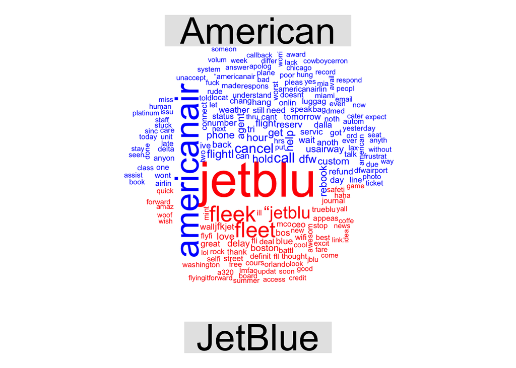

```r
#make the comparison word cloud
comparison.cloud(tdm_both_sum, random.order = FALSE,
                 colors = c("blue", "red"), max.words = 200)
```

After you’ve done this, summarize your main takeaways from the word cloud in 1-2 sentences.

*Generally speaking, it seems like American tends to have more words related to flight logistics (e.g., cancel, rebook, call, hold), whereas JetBlue has a mix of other words that tend more positive (e.g., love, great, awesome, and of course fleek). We can also note that some city locations are on either side of the word cloud: In American, we can see Dallas and DFW (the Dallas airport, where American Airlines is based), and in JetBlue we can see JFK (the New York City airport) and Boston (the city where JetBlue is based).*

# Problem 3: This is our last lab…Feeling sentimental? (25 points)

Now we will explore the `airline_sentiment` column in `airline_tweets`, which labels each tweet as either “positive”, “negative”, or “neutral”.

1. (10pts) Let’s first see if the dataset’s categorization of each tweet as “positive”, “negative”, or “neutral” is sensible. To get you started, the following code defines three subsets (one for each sentiment), processes the text in those subsets, and creates corresponding Document-Term matrices:

```r
#subsets for different sentiments
positive <- filter(airline_tweets, airline_sentiment == "positive")
negative <- filter(airline_tweets, airline_sentiment == "negative")
neutral <- filter(airline_tweets, airline_sentiment == "neutral")

#preprocessing the text for each airline
positive.text = preprocessText(positive$text)
negative.text = preprocessText(negative$text)
neutral.text = preprocessText(neutral$text)

#creating the document-term matrices
dtm.tweets.positive = DocumentTermMatrix(positive.text, control = list(stopwords = TRUE, stemming = TRUE))
dtm.tweets.negative = DocumentTermMatrix(negative.text, control = list(stopwords = TRUE, stemming = TRUE))
dtm.tweets.neutral = DocumentTermMatrix(neutral.text, control = list(stopwords = TRUE, stemming = TRUE))
```

Using these Document-Term matrices, create a word cloud for each sentiment. Similar to what you did in Problem 2A, arrange the results into a 1x3 grid using `par(mfrow=c(1,3))`. So that your word clouds fully display, please use the following code block when displaying your word clouds:

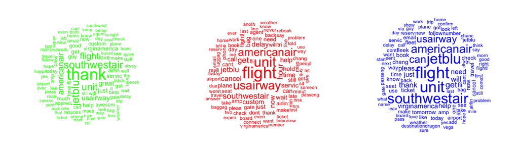

```r
par(mar = c(1, 2, 1, 2))

#getting the words and their frequencies
tweets.positive.words = colnames(dtm.tweets.positive)
tweets.positive.freqs = colSums(as.matrix(dtm.tweets.positive))

tweets.negative.words = colnames(dtm.tweets.negative)
tweets.negative.freqs = colSums(as.matrix(dtm.tweets.negative))

tweets.neutral.words = colnames(dtm.tweets.neutral)
tweets.neutral.freqs = colSums(as.matrix(dtm.tweets.neutral))

#arrange the word clouds in a grid
par(mfrow=c(1,3))
wordcloud(words = tweets.positive.words, freq = tweets.positive.freqs, max.words = 100,
    random.order = FALSE, colors = "green", scale=c(2,.5))
wordcloud(words = tweets.negative.words, freq = tweets.negative.freqs, max.words = 100,
    random.order = FALSE, colors = "red", scale=c(2,.5))
wordcloud(words = tweets.neutral.words, freq = tweets.neutral.freqs, max.words = 100,
    random.order = FALSE, colors = "blue", scale=c(2,.5))
```

Please also set each word cloud to a different color, such that it is easier to differentiate each word cloud. For this part, all you have to do is display the three word clouds. But, it can be useful to think about whether the three word clouds are surprising, given that they are supposed to be displaying frequent words for “positive”, “negative”, and “neutral” tweets.

2. (15pts) As a review of old material, let’s consider which airlines tend to get different kinds of sentiment, at least in terms of their tweets. In particular, answer the following questions:
- Use a statistical test to assess if the proportion of *negative tweets* is significantly different across airlines. Note that, for any given `airline`, the proportion of negative tweets is (1) the total number of tweets such that `airline_tweets == "negative"` divided by (2) the total number of tweets about that `airline`. Thus, to answer this question, you can use `prop.test(x, n)`, where `x` is set to the vector of negative tweets for each airline, and `n` is set to the vector of total tweets for each airline. (**Hint**: You can use the `table()` function to easily get these vectors.) After you write your `prop.test()` code, be sure to write your formal conclusion from the statistical test.

*There are a few ways you could define the vectors of total negative tweets and total tweets; I’ll demonstrate one way just using the `table()` function. First, note that this is the contingency table for `airline` and `airline_sentiment`:*

```r
table(airline_tweets$airline, airline_tweets$airline_sentiment)
```

```
##
##                  negative neutral positive
##   American           1960     463      336
##   JetBlue             955     723      544
##   Southwest          1186     664      570
##   United             2633     697      492
##   US Airways         2263     381      269
##   Virgin America      181     171      152
```

*The first column corresponds to the total numbers of negative tweets, and the row sums correspond to the total numbers of tweets. Thus, we can define the desired vectors in this way:*

```r
negativeTweetTotals = table(airline_tweets$airline, airline_tweets$airline_sentiment)[,1]
tweetTotals =  rowSums(table(airline_tweets$airline, airline_tweets$airline_sentiment))
```

*Then, we can run `prop.test()`:*

```r
prop.test(x = negativeTweetTotals, n = tweetTotals)
```

```
##
##  6-sample test for equality of proportions without continuity
##  correction
##
## data:  negativeTweetTotals out of tweetTotals
## X-squared = 1142.4, df = 5, p-value < 2.2e-16
## alternative hypothesis: two.sided
## sample estimates:
##    prop 1    prop 2    prop 3    prop 4    prop 5    prop 6
## 0.7104023 0.4297930 0.4900826 0.6889063 0.7768623 0.3591270
```

*We see that the p-value is nearly 0; thus, we reject the null hypothesis that the negative tweet proportions are equal, thereby concluding that they are different.*

- Consider the proportion of (1) negative tweets, (2) positive tweets, and (3) neutral tweets for each airline. Among these three proportions, which airlines have negative tweets as the highest proportion? (In other words, which airlines have a plurality of negative tweets?) After you’ve answered that question: Does this make sense, given the context of the data? (**Hint**: Remember, most of these Tweets are made while someone is waiting to board a flight.)

*There are several ways that you can compute the (1) negative, (2) positive, and (3) neutral proportions for each airline (indeed, we computed the negative proportions in the previous part, and we could repeat the same process for positive and neutral). Instead, we will use the `prop.table()` function (which we actually saw in our first lab!)*

```r
prop.table(table(airline_tweets$airline, airline_tweets$airline_sentiment), margin = 1)
```

```
##
##                    negative    neutral   positive
##   American       0.71040232 0.16781443 0.12178325
##   JetBlue        0.42979298 0.32538254 0.24482448
##   Southwest      0.49008264 0.27438017 0.23553719
##   United         0.68890633 0.18236525 0.12872841
##   US Airways     0.77686234 0.13079300 0.09234466
##   Virgin America 0.35912698 0.33928571 0.30158730
```

*Note that each row adds up to 1; thus, each row displays the proportion of negative, positive, and neutral tweets for each airline. We can see that all airlines have their plurality of tweets as negative tweets (i.e., in each row, the negative number is higher than the other two numbers). This is unfortunate for the airlines, but it is intuitive: This finding makes sense given the context of the data, because I imagine that most people would have the gumption to tweet about an airline only when they have a complaint about that airline, especially when they are waiting to board a flight.*